# Urdu Language Sentiment Classifier

# 1 Description of Problem

- *Background*: A large multinational corporation is seeking to automatically identify the sentiment that their customer base talks about on social media. They would like to expand this capability into multiple languages. Many 3rd party tools exist for sentiment analysis, however, they need help with under-resourced languages.
- *Goal*: Train a sentiment classifier (Positive, Negative, Neutral) on a corpus of the provided documents. Your goal is to maximize accuracy. There is special interest in being able to accurately detect negative sentiment. The training data includes documents from a wide variety of sources, not merely social media, and some of it may be inconsistently labeled. Please describe the business outcomes in your work sample including how data limitations impact your results and how these limitations could be addressed in a larger project.
- *Data*: Link to data: http://archive.ics.uci.edu/ml/datasets/Roman+Urdu+Data+Set

# 2 Analyze input file

Load packages

```r
library(tidyverse)
library(tm)
library(xgboost)
library(h2o)
```

Source file

```r
fname <- "data/Roman Urdu DataSet.csv"
```

Encoding is UTF-8

```r
guess_encoding(fname)
```

```
## # A tibble: 3 x 2
##   encoding     confidence
##   <chr>             <dbl>
## 1 UTF-8             1
## 2 windows-1252      0.290
## 3 windows-1254      0.290
```

Look at the first few lines of file:

- comma separated, header is missing

```r
read_lines(fname,n_max = 3)
```

```
## [1] "Sai kha ya her kisi kay bus ki bat nhi hai lakin main ki hal kal bi Aj aur aj bi sirf Aus say bus,Positive,"
## [2] "sahi bt h,Positive,"
## [3] "\"Kya bt hai,\",Positive,"
```

Reads 3-col csv as characters

```r
df_urdu <- read_csv("data/Roman Urdu DataSet.csv",col_names = c("phrase","sentiment","bogus"),
                    col_types = "ccc", # all are chars
                    #n_max=3
                    )
df_urdu %>% glimpse
```

```
## Rows: 20,229
## Columns: 3
## $ phrase    <chr> "Sai kha ya her kisi kay bus ki bat nhi hai lakin main ki...
## $ sentiment <chr> "Positive", "Positive", "Positive", "Positive", "Positive...
## $ bogus     <chr> NA, NA, NA, NA, NA, NA, NA, NA, NA, NA, NA, NA, NA, NA, N...
```

Third column can truly be ignored

```r
df_urdu %>% count(bogus,sort=T)
```

```
## # A tibble: 7 x 2
##   bogus                n
##   <chr>            <int>
## 1 <NA>             20222
## 2 till here            2
## 3 ------               1
## 4 -------              1
## 5 ----------           1
## 6 ----------------     1
## 7 9090                 1
```

Categories on sentiment column:

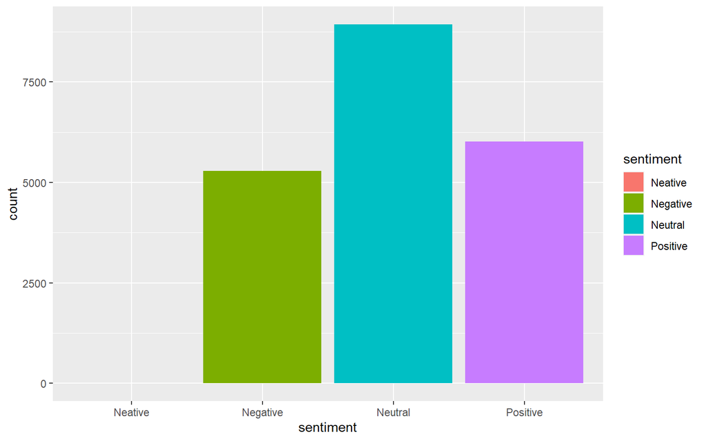

```r
df_urdu %>%
  ggplot(aes(sentiment,fill=sentiment)) +
  geom_bar()
```

One sacred line with “Neative”, what is it?

```r
df_urdu %>% filter(sentiment == "Neative")
```

```
## # A tibble: 1 x 3
##   phrase                                               sentiment bogus
##   <chr>                                                <chr>     <chr>
## 1 product achi hai but wrong waist size send kar diya. Neative   <NA>
```

A few lines have NA phrases, which need to be removed.

```r
df_urdu %>%
  filter(is.na(phrase))
```

```
## # A tibble: 113 x 3
##    phrase sentiment bogus
##    <chr>  <chr>     <chr>
##  1 <NA>   Neutral   <NA>
##  2 <NA>   Neutral   <NA>
##  3 <NA>   Neutral   <NA>
##  4 <NA>   Neutral   <NA>
##  5 <NA>   Neutral   <NA>
##  6 <NA>   Neutral   <NA>
##  7 <NA>   Neutral   <NA>
##  8 <NA>   Neutral   <NA>
##  9 <NA>   Neutral   <NA>
## 10 <NA>   Neutral   <NA>
## # ... with 103 more rows
```

## 2.1 Study characters in the set

```r
df_urdu$phrase[1] %>% str_split("")
```

```
## [[1]]
##  [1] "S" "a" "i" " " "k" "h" "a" " " "y" "a" " " "h" "e" "r" " " "k" "i" "s" "i"
## [20] " " "k" "a" "y" " " "b" "u" "s" " " "k" "i" " " "b" "a" "t" " " "n" "h" "i"
## [39] " " "h" "a" "i" " " "l" "a" "k" "i" "n" " " "m" "a" "i" "n" " " "k" "i" " "
## [58] "h" "a" "l" " " "k" "a" "l" " " "b" "i" " " "A" "j" " " "a" "u" "r" " " "a"
## [77] "j" " " "b" "i" " " "s" "i" "r" "f" " " "A" "u" "s" " " "s" "a" "y" " " "b"
## [96] "u" "s"
```

Frequency count of all chars used

```r
count_chars <- function(df,col) {
  df %>%  # head(10) %>%
  mutate(chars = {{col}} %>% str_split("")) %>%
  select(chars) %>%
  unnest(chars) %>%
  count(chars,sort=T) %>%
  mutate(prop=sprintf("%.3f",n/sum(n)))
}
```

```r
df_char_freq <- df_urdu %>% count_chars(phrase)
df_char_freq%>%glimpse
```

```
## Rows: 272
## Columns: 3
## $ chars <chr> " ", "a", "i", "e", "h", "n", "r", "k", "t", "o", "s", "m", "...
## $ n     <int> 251023, 193318, 89650, 82255, 79466, 63038, 57748, 52567, 470...
## $ prop  <chr> "0.183", "0.141", "0.065", "0.060", "0.058", "0.046", "0.042"...
```

```r
df_char_freq %>% filter(!str_detect(chars,"[:alpha:]"))
```

```
## # A tibble: 183 x 3
##    chars             n prop
##    <chr>         <int> <chr>
##  1 " "          251023 0.183
##  2 "."           10159 0.007
##  3 ","            2761 0.002
##  4 "1"            2466 0.002
##  5 "0"            1633 0.001
##  6 "?"            1599 0.001
##  7 "9"            1584 0.001
##  8 "\U0001f602"   1506 0.001
##  9 "2"            1357 0.001
## 10 ":"             959 0.001
## # ... with 173 more rows
```

Preprocessing steps:

- eliminate NA phrases
- change ‘Neative’ to ‘Negative’
- eliminate non-alpha (includes numbers)
- convert all to lower-case
- squish multiple spaces

```r
df_urdu_clean <- df_urdu %>%
  filter(!is.na(phrase)) %>%
  mutate(sentiment=if_else(sentiment=="Neative","Negative",sentiment)) %>%
  mutate(phrase_clean=phrase %>%
           str_remove_all("[^ [:alpha:]]") %>%
           str_to_lower() %>%
           str_squish()) %>%
  select(phrase_clean,sentiment)
df_urdu_clean %>% head(10)
```

```
## # A tibble: 10 x 2
##    phrase_clean                                                        sentiment
##    <chr>                                                               <chr>
##  1 sai kha ya her kisi kay bus ki bat nhi hai lakin main ki hal kal b~ Positive
##  2 sahi bt h                                                           Positive
##  3 kya bt hai                                                          Positive
##  4 wah je wah                                                          Positive
##  5 are wha kaya bat hai                                                Positive
##  6 wah kya baat likhi                                                  Positive
##  7 wha itni sari khubiya                                               Positive
##  8 itni khubiya                                                        Positive
##  9 ya allah rehm farma hm sab pe or zalimo ko hidayat de ameen         Positive
## 10 please everyone allah swt ka naam hamesha bary lawzo main likha ka~ Positive
```

Confirm chars are ok

```r
df_urdu_clean %>% count_chars(phrase_clean)
```

```
## # A tibble: 62 x 3
##    chars      n prop
##    <chr>  <int> <chr>
##  1 " "   241819 0.182
##  2 "a"   201695 0.152
##  3 "i"    92547 0.070
##  4 "e"    83985 0.063
##  5 "h"    83624 0.063
##  6 "n"    65396 0.049
##  7 "r"    59609 0.045
##  8 "k"    58021 0.044
##  9 "t"    49364 0.037
## 10 "s"    48592 0.037
## # ... with 52 more rows
```

# 3 Token-oriented study

```r
df_urdu_tokens <- df_urdu_clean %>%
  mutate(token = str_split(phrase_clean,fixed(" "))) %>%
  select(token) %>%
  unnest(token) %>%
  count(token,sort=T) %>%
  mutate(id=row_number(),
         prop=n/sum(n),
         propSum=cumsum(prop))
df_urdu_tokens
```

```
## # A tibble: 32,734 x 5
##    token     n    id    prop propSum
##    <chr> <int> <int>   <dbl>   <dbl>
##  1 ki     5758     1 0.0220   0.0220
##  2 ke     5354     2 0.0204   0.0424
##  3 mein   4361     3 0.0166   0.0591
##  4 hai    3913     4 0.0149   0.0740
##  5 ka     3586     5 0.0137   0.0877
##  6 ko     3572     6 0.0136   0.101
##  7 se     3237     7 0.0124   0.114
##  8 aur    3173     8 0.0121   0.126
##  9 k      2810     9 0.0107   0.137
## 10 ne     2055    10 0.00785  0.144
## # ... with 32,724 more rows
```

## 3.1 Build Document Term Matrix

Create term matrix. Each rows has the count of the top N tokens

```r
corpus_urdu <- SimpleCorpus(VectorSource(df_urdu_clean$phrase_clean))
```

Creat a document term matrix

```r
fn_tf_idf <- function(x) weightTfIdf(x, normalize = F)

dtm_urdu <- DocumentTermMatrix(corpus_urdu
                               #, control = list(weighting = tfidf_fn)
                               )
dtm_urdu
```

```
## <<DocumentTermMatrix (documents: 20116, terms: 32360)>>
## Non-/sparse entries: 186715/650767045
## Sparsity           : 100%
## Maximal term length: 82
## Weighting          : term frequency (tf)
```

```r
mtx <- inspect(dtm_urdu[1:10,1:100]) %>% as.matrix
```

```
## <<DocumentTermMatrix (documents: 10, terms: 100)>>
## Non-/sparse entries: 59/941
## Sparsity           : 94%
## Maximal term length: 9
## Weighting          : term frequency (tf)
## Sample             :
##     Terms
## Docs bat bus hai itni khubiya kya main say wah wha
##   1    1   2   1    0       0   0    1   1   0   0
##   10   0   0   0    0       0   0    1   1   0   0
##   2    0   0   0    0       0   0    0   0   0   0
##   3    0   0   1    0       0   1    0   0   0   0
##   4    0   0   0    0       0   0    0   0   2   0
##   5    1   0   1    0       0   0    0   0   0   1
##   6    0   0   0    0       0   1    0   0   1   0
##   7    0   0   0    1       1   0    0   0   0   1
##   8    0   0   0    1       1   0    0   0   0   0
##   9    0   0   0    0       0   0    0   0   0   0
```

```r
mtx %>% dim
```

```
## [1] 10 10
```

Note: 99.8% sparsity => 673 columns, AUC ~ 75% 995 => ~200 columns, AUC falls to 70%

```r
df_urdu_dtm <- removeSparseTerms(dtm_urdu, 0.998) %>% as.matrix %>% as_tibble
df_urdu_dtm %>% dim
```

```
## [1] 20116   673
```

# 4 Train ML models

```r
h2o.init()
```

```
##  Connection successful!
##
## R is connected to the H2O cluster:
##     H2O cluster uptime:         11 hours 39 minutes
##     H2O cluster timezone:       America/Sao_Paulo
##     H2O data parsing timezone:  UTC
##     H2O cluster version:        3.30.0.1
##     H2O cluster version age:    2 months and 26 days
##     H2O cluster name:           H2O_started_from_R_drezn_ajy211
##     H2O cluster total nodes:    1
##     H2O cluster total memory:   3.41 GB
##     H2O cluster total cores:    4
##     H2O cluster allowed cores:  4
##     H2O cluster healthy:        TRUE
##     H2O Connection ip:          localhost
##     H2O Connection port:        54321
##     H2O Connection proxy:       NA
##     H2O Internal Security:      FALSE
##     H2O API Extensions:         Amazon S3, Algos, AutoML, Core V3, TargetEncoder, Core V4
##     R Version:                  R version 4.0.2 (2020-06-22)
```

```r
# h2o.shutdown()
```

XGBoost only available on mac or linux

```r
h2o.xgboost.available()
```

Slow: do any of the columns have NA

```r
any_na <- function(vals) any(is.na(vals))

df_urdu_mtx %>% as_tibble %>%
  mutate(has_na=pmap_lgl(.,~any_na(list(...)))) %>%
  filter(has_na)
```

Convert to h2o matrix

Bring sentiment column: allocate twice the weight to Negative which becomes the “TRUE”

```r
df_urdu_dtm_y <- df_urdu_dtm %>%
  bind_cols(df_urdu_clean %>% select(sentiment) %>%
              mutate_at(vars(sentiment),as.factor)) %>%
  # double the weight on negatives
  mutate(weight=if_else(sentiment=="Negative",2,1)) %>%
  select(sentiment,weight,everything()) %>%
  # filter(sentiment!="Neutral") %>%
  mutate(sentiment=sentiment=="Negative")
```

Cast to h2o data frame

```r
df_urdu_h2o <- df_urdu_dtm_y %>%
  as.h2o()
df_urdu_h2o
```

AutoML main call (trains a bunch models, with 5-fold CV), 720s

```r
ml_urdu <- h2o::h2o.automl(y="sentiment",
                           weights_column = "weight",
                           training_frame=df_urdu_h2o,
                           max_runtime_secs = 720,
                           seed=0,
                           stopping_metric = "misclassification")
```

Write leaderboard to file

```r
ml_urdu@leaderboard %>% as_tibble %>% write_csv("leaderboard.csv")
```

Recover leaderboard

```r
df_leaderboard <- read_csv("leaderboard.csv")
```

Show leader board, getting ~74% AUC

```r
df_leaderboard %>%
  mutate(model_id=str_sub(model_id,end=20)) # %>%
```

```
## # A tibble: 18 x 7
##    model_id               auc logloss aucpr mean_per_class_error  rmse   mse
##    <chr>                <dbl>   <dbl> <dbl>                <dbl> <dbl> <dbl>
##  1 StackedEnsemble_AllM 0.746   0.494 0.546                0.320 0.403 0.162
##  2 StackedEnsemble_Best 0.745   0.495 0.545                0.320 0.403 0.162
##  3 GLM_1_AutoML_2020063 0.739   0.587 0.677                0.364 0.449 0.201
##  4 GBM_grid__1_AutoML_2 0.717   0.609 0.663                0.390 0.459 0.211
##  5 GBM_grid__1_AutoML_2 0.712   0.615 0.658                0.399 0.462 0.214
##  6 DRF_1_AutoML_2020063 0.700   0.630 0.644                0.404 0.469 0.220
##  7 GBM_grid__1_AutoML_2 0.700   0.618 0.648                0.403 0.463 0.215
##  8 GBM_grid__1_AutoML_2 0.693   0.629 0.638                0.409 0.468 0.219
##  9 GBM_4_AutoML_2020063 0.669   0.640 0.621                0.433 0.474 0.224
## 10 GBM_3_AutoML_2020063 0.664   0.642 0.618                0.437 0.474 0.225
## 11 GBM_5_AutoML_2020063 0.661   0.646 0.593                0.443 0.477 0.227
## 12 GBM_1_AutoML_2020063 0.661   0.642 0.611                0.433 0.475 0.226
## 13 GBM_2_AutoML_2020063 0.660   0.643 0.612                0.432 0.475 0.226
## 14 GBM_grid__1_AutoML_2 0.597   0.668 0.547                0.486 0.487 0.238
## 15 XRT_1_AutoML_2020063 0.541   0.680 0.468                0.495 0.494 0.244
## 16 DeepLearning_grid__1 0.538   9.83  0.465                0.5   0.633 0.401
## 17 DeepLearning_grid__2 0.530   4.91  0.472                0.5   0.620 0.385
## 18 DeepLearning_1_AutoM 0.519   5.14  0.448                0.5   0.640 0.409
```

```r
  #knitr::kable() %>%
  #kableExtra::kable_styling(bootstrap_options = c("striped", "hover", "condensed")
#)
```

Save names of models and models to file (to be able to retrieve order)

```r
ml_urdu@leaderboard$model_id %>%
  as_tibble %>%
  write_csv("saved_models.csv")

ml_urdu@leaderboard$model_id %>%
  as.data.frame %>% pull(model_id) %>%
  head(6) %>%
  walk(~h2o.saveModel(h2o.getModel(.x),path="models",force=T))
```

Read saved models list

```r
df_saved_models <- read_csv("saved_models.csv")
```

Retrieve saved models as h2o model objects

```r
list_loaded_models <- df_saved_models$model_id %>%
  head(6) %>%
  map(~h2o.loadModel(str_c("models/",.x)))
```

```r
h2o.confusionMatrix(list_loaded_models[[1]])
```

```
## Confusion Matrix (vertical: actual; across: predicted)  for max f1 @ threshold = 0.280899316839715:
##        FALSE TRUE    Error         Rate
## FALSE  11202 3627 0.244588  =3627/14829
## TRUE    1660 3627 0.313978   =1660/5287
## Totals 12862 7254 0.262826  =5287/20116
```

Plot AUC curve for 1st non-stacked model

```r
model_non_stacked <- list_loaded_models%>%discard(~str_starts(.x@model_id,"Stacked"))%>%first
model_non_stacked@model_id
```

```
## [1] "GLM_1_AutoML_20200630_085522"
```

Plot AUC of top non-stacked model

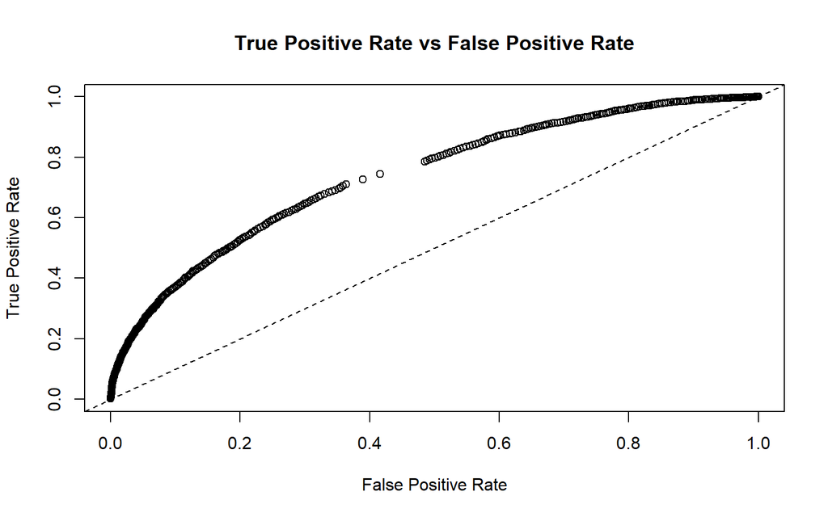

```r
plot(model_non_stacked%>%h2o.performance(xval=T),type="roc")
```

Plot variable importance for the first non-stacked model

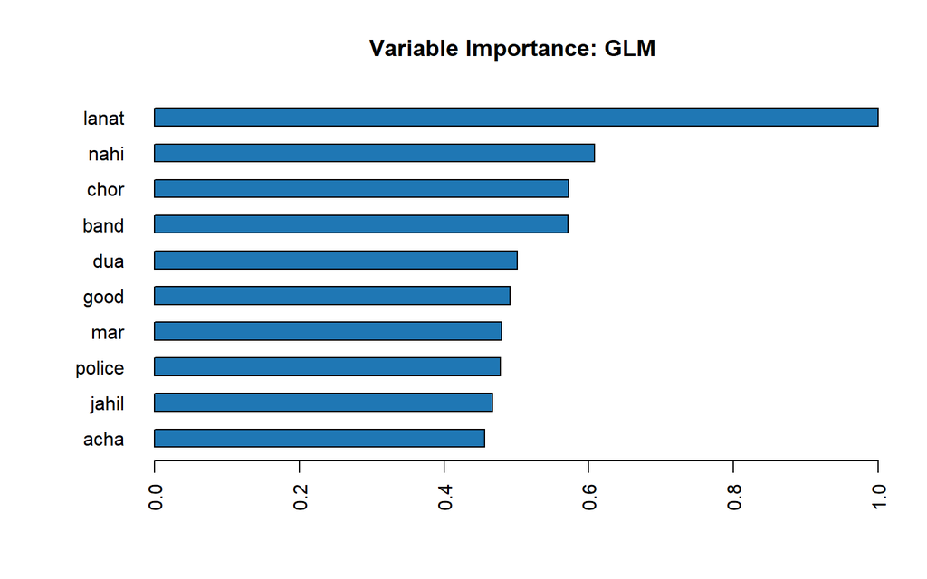

```r
h2o.varimp_plot(model_non_stacked)
```

```r
h2o::h2o.shutdown()
```

```
## Are you sure you want to shutdown the H2O instance running at http://localhost:54321/ (Y/N)?
```

# 5 Business outcomes and Next Steps

## 5.1 Business value

Assess individual or group sentiment of tweets, chats, etc. so as to: - Plan, train, alert customer care representatives - Fine-tune marketing messages which optimize sentiment - Quickly identify disgruntled employees, users, customers, bad brand interaction, etc.

## 5.2 Suggested next steps

- Dataset
  - The sample is small (20k snippets), though the quality is generally good
- Potential fine-tunings to current approach
  - Play with sparsity threshold to include more or less words into vocabulary.
  - Use non-linear of dimensionality reduction, e.g. t-SNE, see picture below,
  - Test Union(Neutral,Positive) vs Negative
  - Use XGBoost, needs h2o on Linux or Mac
  - Could have separate classifier for “Neutral”
- Tried but ineffective
  - 3-class positive, negative, neutral (non-lumped)
  - PCA (no effective compression)
  - Play with TF*IDF on document term matrix (initial tests were not good)
- Other approaches
  - Translate Urdu words into English and augment with English positive/negative sentiment word tables.
  - Augment the “bag of words” approach with order-depedency (use non-sparse 2- and 3-word sequences as features).
  - Use some order dependency to corroborate sentiment, LSTM or HMMs come to mind
  - Build correlation matrices of each of the non-sparse unique words and the positive/negative/neutral labels. Do a naive-bayes and/or perceptron classifier. Blend its predictions w/ the best ML one

## 5.3 Types of dimensionality reduction

[source](https://cran.r-project.org/web/packages/dimRed/vignettes/dimensionality-reduction.pdf)

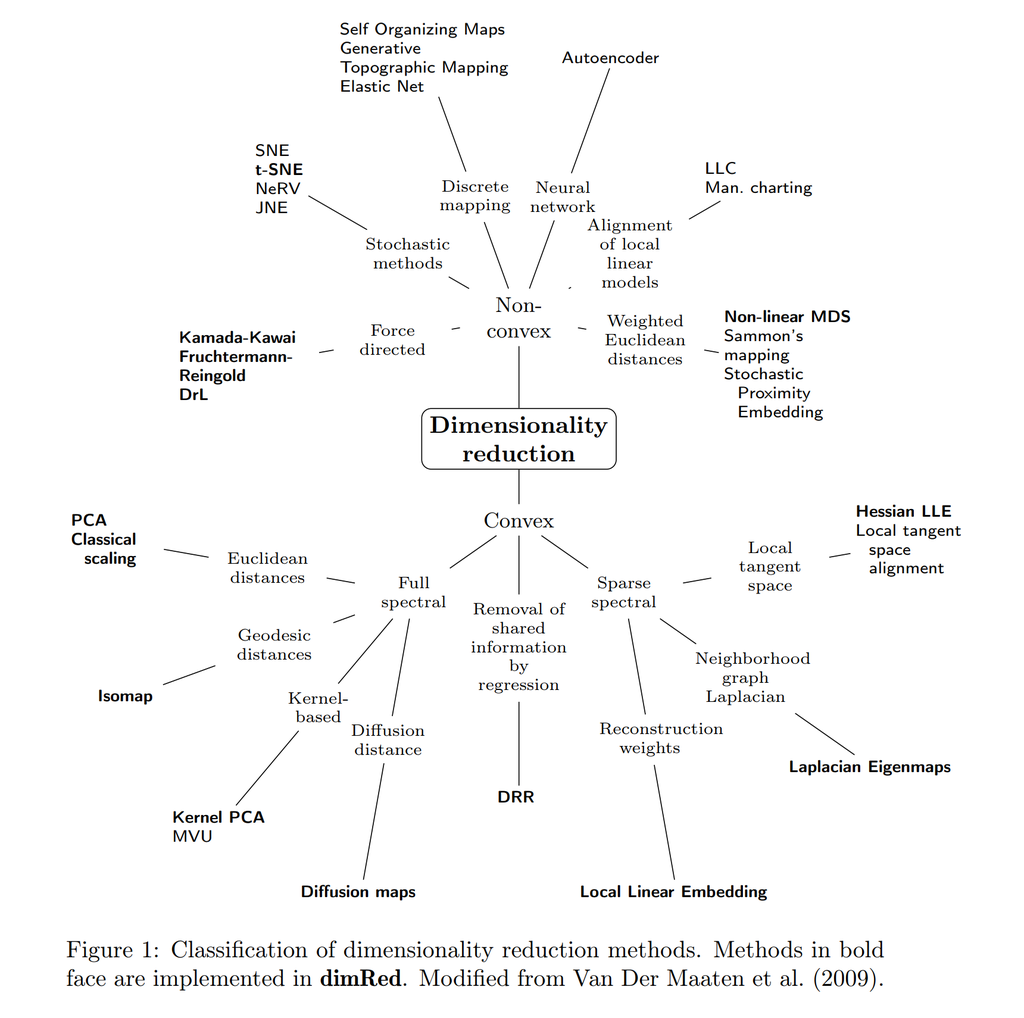